# Tornados and Floods Are the Storms That Have the Most Impact on Population Health and the Economy Respectively

## Synopsis

In this report we aim to show which types of storms that have are most harmful to population health as well as which types of storms have the greatest economic consequences. To accomplish this we analyzed data downloaded from the U.S. National Oceanic and Atmospheric Administration’s (NOAA) storm database. From this data, we found that between 1950 and November 2011, the timeframe that the databased covered, tornadoes were responsible for the greatest cumulative harm on population health, with more deaths and more injuries attributed to tornadoes than any other storm type by a wide margin. Additionally we found that during the same time period floods were the storm type that had the greatest economic consequences. Despite the fact that drought was clearly responsible for the greatest cumulative crop damage during the measured period, the property damage associated with flooding caused floods to dwarf drought when analyzing the total economic impact of both property damage and crop damage combined.

## Data Processing

Loading Data:  
We load the data into R that was downloaded from the NOAA storm database, decompressing the file if it has not been done so already.

```r
##check to see if data is decompressed, if it isn't then decompress it
library(R.utils)
if (!file.exists("repdata-data-StormData.csv")){
        bunzip2("repdata-data-StormData.csv.bz2")
}
data <- read.csv("repdata-data-StormData.csv")
head(data)
```

```
##   STATE__           BGN_DATE BGN_TIME TIME_ZONE COUNTY COUNTYNAME STATE
## 1       1  4/18/1950 0:00:00     0130       CST     97     MOBILE    AL
## 2       1  4/18/1950 0:00:00     0145       CST      3    BALDWIN    AL
## 3       1  2/20/1951 0:00:00     1600       CST     57    FAYETTE    AL
## 4       1   6/8/1951 0:00:00     0900       CST     89    MADISON    AL
## 5       1 11/15/1951 0:00:00     1500       CST     43    CULLMAN    AL
## 6       1 11/15/1951 0:00:00     2000       CST     77 LAUDERDALE    AL
##    EVTYPE BGN_RANGE BGN_AZI BGN_LOCATI END_DATE END_TIME COUNTY_END
## 1 TORNADO         0                                               0
## 2 TORNADO         0                                               0
## 3 TORNADO         0                                               0
## 4 TORNADO         0                                               0
## 5 TORNADO         0                                               0
## 6 TORNADO         0                                               0
##   COUNTYENDN END_RANGE END_AZI END_LOCATI LENGTH WIDTH F MAG FATALITIES
```

[output cut: 20 more lines]

Data Processing:  
1. Select only the EVTYPE column and the columns relating to physical health and economic damage. (EVTYPE, FATALITIES, INJURIES, PROPDMG, PROPDMGEXP, CROPDMG, CROPDMGEXP).  
2. Change all names, as well as the values of the exponent fields, to lowercase to make them easier to work with.  
3. Replace the exponent codes with the proper multiplier and then multiply those multipliers by the observed values.  
4. Select only the evtype, fatalities, injuries, propDamage, and cropDamage columns.

```r
##select columns using select function in dplyr library
library(dplyr)
data <- select(data, EVTYPE, FATALITIES, INJURIES, PROPDMG, PROPDMGEXP, CROPDMG, CROPDMGEXP)

## change names to lowercase
names(data) <- tolower(names(data))

## change exponent fields to lowercase
data$propdmgexp <- tolower(data$propdmgexp)
data$cropdmgexp <- tolower(data$cropdmgexp)

## replace the exponents with numeric values
data$propdmgexp <- gsub("h", "100", data$propdmgexp)
data$propdmgexp <- gsub("k", "1000", data$propdmgexp)
data$propdmgexp <- gsub("m", "1000000", data$propdmgexp)
data$propdmgexp <- gsub("b", "1000000000", data$propdmgexp)

data$cropdmgexp <- gsub("h", "100", data$cropdmgexp)
data$cropdmgexp <- gsub("k", "1000", data$cropdmgexp)
data$cropdmgexp <- gsub("m", "1000000", data$cropdmgexp)
data$cropdmgexp <- gsub("b", "1000000000", data$cropdmgexp)

data$propdmgexp <- as.numeric(data$propdmgexp)
data$cropdmgexp <- as.numeric(data$cropdmgexp)

##add propdamage and cropdamage fields
data <- mutate(data, propDamage = propdmg * propdmgexp, cropDamage = cropdmg * cropdmgexp)

##subset the dataset to only exclude the propdmg, propdmgexp, cropdmg,
##cropdmgexp columns
data <- select(data, evtype, fatalities, injuries, propDamage, cropDamage)

head(data)
```

```
##    evtype fatalities injuries propDamage cropDamage
## 1 TORNADO          0       15      25000         NA
## 2 TORNADO          0        0       2500         NA
## 3 TORNADO          0        2      25000         NA
## 4 TORNADO          0        2       2500         NA
## 5 TORNADO          0        2       2500         NA
## 6 TORNADO          0        6       2500         NA
```

5. Group data based on event type.

```r
##group data by evtype, find number of injuries and fatalities for each event
groupedData <- group_by(data, evtype)

head(groupedData)
```

```
## Source: local data frame [6 x 5]
## Groups: evtype
##
##    evtype fatalities injuries propDamage cropDamage
## 1 TORNADO          0       15      25000         NA
## 2 TORNADO          0        0       2500         NA
## 3 TORNADO          0        2      25000         NA
## 4 TORNADO          0        2       2500         NA
## 5 TORNADO          0        2       2500         NA
## 6 TORNADO          0        6       2500         NA
```

6. Process and subset data for effects on public health: get cumulative sum for each column for each event, add column showing sum of both injuries and fatalities, convert evtype values to title case.

```r
healthEffect <- summarise(groupedData, deaths=sum(fatalities, na.rm=TRUE), injured=sum(injuries, na.rm=TRUE))

##add column 'incidents' that is total of both injuries and fatalities
healthEffect <- mutate(healthEffect, incidents = deaths + injured)

##convert event types to title case
events <- healthEffect[,1]
events <- gsub("\\b([A-Z])([A-Z]+)", "\\U\\1\\L\\2" ,events, perl=TRUE)
healthEffect[,1] <- events

head(healthEffect)
```

```
## Source: local data frame [6 x 4]
##
##                  evtype deaths injured incidents
## 1    High Surf Advisory      0       0         0
## 2         Coastal Flood      0       0         0
## 3           Flash Flood      0       0         0
## 4             Lightning      0       0         0
## 5             Tstm Wind      0       0         0
## 6       Tstm Wind (G45)      0       0         0
```

7. Process and subset data for economic impact: get cumulative sum for each column for each event, add column showing sum of both property damage and crop damage, convert evtype values to title case.

```r
ecoEffect <- summarise(groupedData, propDamage=sum(propDamage, na.rm=TRUE), cropDamage=sum(cropDamage, na.rm=TRUE))

##add column 'incidents' that is total of both injuries and fatalities
ecoEffect <- mutate(ecoEffect, totalDamage = propDamage + cropDamage)

##convert event types to title case
events <- ecoEffect[,1]
events <- gsub("\\b([A-Z])([A-Z]+)", "\\U\\1\\L\\2" ,events, perl=TRUE)
ecoEffect[,1] <- events

head(ecoEffect)
```

```
## Source: local data frame [6 x 4]
##
##                  evtype propDamage cropDamage totalDamage
## 1    High Surf Advisory     200000          0      200000
## 2         Coastal Flood          0          0           0
## 3           Flash Flood      50000          0       50000
## 4             Lightning          0          0           0
## 5             Tstm Wind    8100000          0     8100000
## 6       Tstm Wind (G45)       8000          0        8000
```

## Results

### Population Health

Find the top 10 events for incidents, defined by the sum of injuries and fatalities.

```r
##subset to the top 10 incidents, melt table so it can be plotted
library(reshape)
n <- 10
topIncidents <- arrange(healthEffect, desc(incidents))[1:n,]
plotData <- as.data.frame(melt(topIncidents))

##replace variables for plot
plotData$variable <- gsub("deaths", "Fatalities", plotData$variable)
plotData$variable <- gsub("incidents", "Fatalities & Injuries", plotData$variable)
plotData$variable <- gsub("injured", "Injuries", plotData$variable)

head(plotData)
```

```
##           evtype   variable value
## 1        Tornado Fatalities  5633
## 2 Excessive Heat Fatalities  1903
## 3      Tstm Wind Fatalities   504
## 4          Flood Fatalities   470
## 5      Lightning Fatalities   816
## 6           Heat Fatalities   937
```

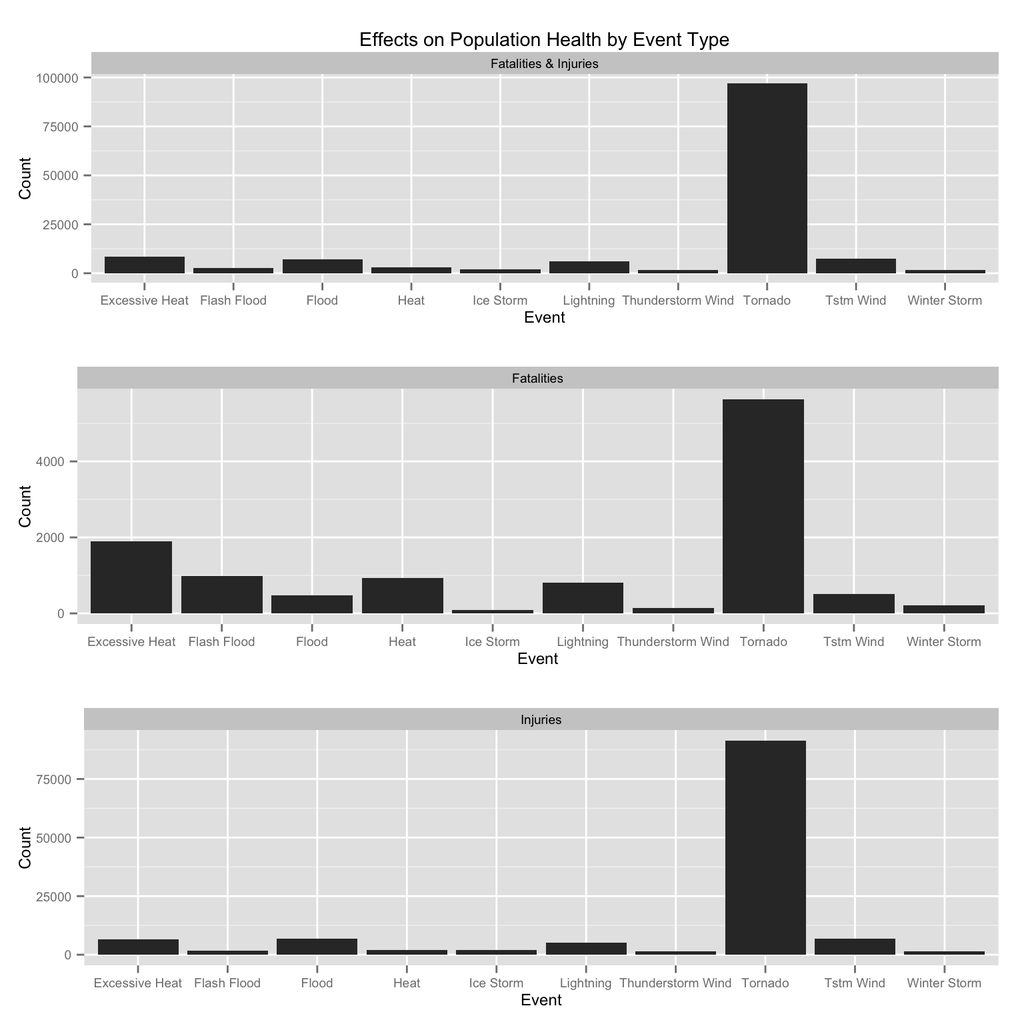

```r
##load gridExtra library, need to plot as 3 charts rather than normal facets so y
##axis is more readable
library(gridExtra)
library(ggplot2)
library(scales)

g1 <- ggplot(subset(plotData, variable == "Fatalities & Injuries"), aes(evtype, value))
g1 <- g1 + geom_bar(stat="identity") + facet_wrap(~variable)
g1 <- g1 + ggtitle("Effects on Population Health by Event Type")
g1 <- g1 + xlab("Event") + ylab("Count")
g1 <- g1 + theme(text = element_text(size=9))

g2 <- ggplot(subset(plotData, variable == "Fatalities"), aes(evtype, value))
g2 <- g2 + geom_bar(stat="identity") + facet_wrap(~variable)
g2 <- g2 + xlab("Event") + ylab("Count")
g2 <- g2 + theme(text = element_text(size=9))

g3 <- ggplot(subset(plotData, variable == "Injuries"), aes(evtype, value))
g3 <- g3 + geom_bar(stat="identity") + facet_wrap(~variable)
g3 <- g3 + xlab("Event") + ylab("Count")
g3 <- g3 + theme(text = element_text(size=9))

grid.arrange(g1,g2,g3)
```

### Economic Consequences

Find the top 10 events for total damage, defined as the sum of crop and property damage.

```r
##subset to the top 10 incidents, melt table so it can be plotted
n <- 10
topEco <- arrange(ecoEffect, desc(totalDamage))[1:n,]
plotData <- as.data.frame(melt(topEco))

##replace variables for plot
plotData$variable <- gsub("cropDamage", "Crop Damage $", plotData$variable)
plotData$variable <- gsub("propDamage", "Property Damage $", plotData$variable)
plotData$variable <- gsub("totalDamage", "Total Damage $", plotData$variable)

head(plotData)
```

```
##              evtype          variable     value
## 1             Flood Property Damage $ 1.447e+11
## 2 Hurricane/Typhoon Property Damage $ 6.931e+10
## 3           Tornado Property Damage $ 5.694e+10
## 4       Storm Surge Property Damage $ 4.332e+10
## 5              Hail Property Damage $ 1.573e+10
## 6       Flash Flood Property Damage $ 1.614e+10
```

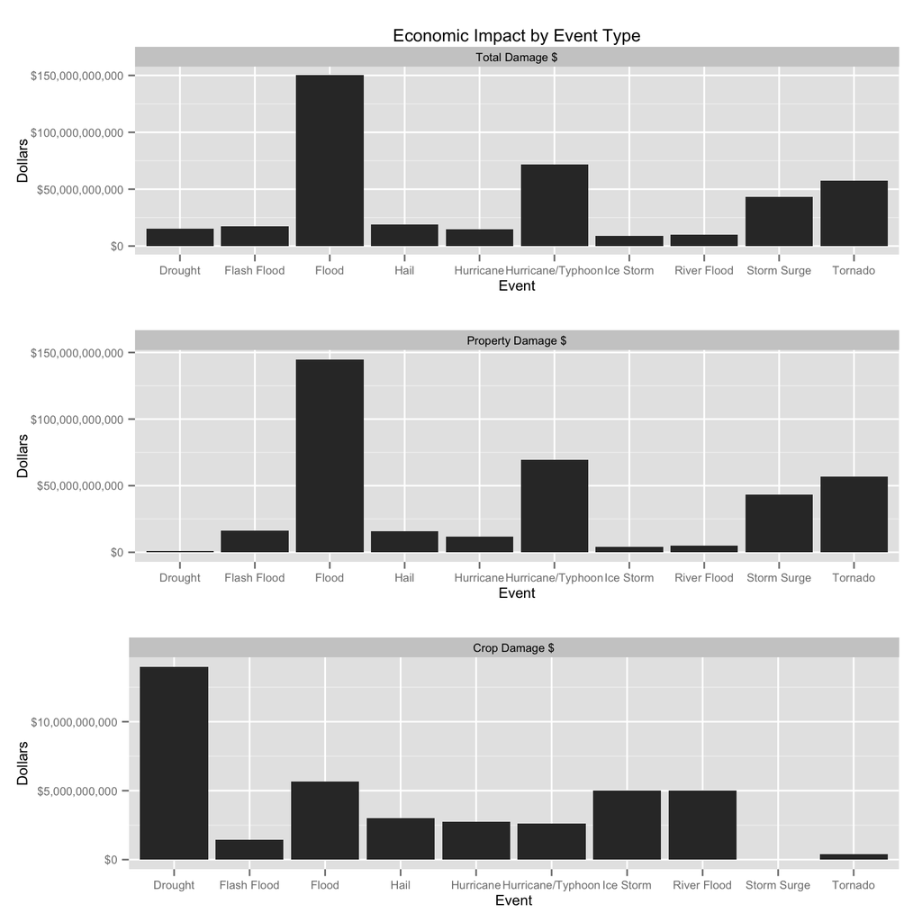

```r
##need to plot as 3 charts rather than normal facets so y axis is more readable

g1 <- ggplot(subset(plotData, variable == "Total Damage $"), aes(evtype, value))
g1 <- g1 + geom_bar(stat="identity") + facet_wrap(~variable)
g1 <- g1 + ggtitle("Economic Impact by Event Type")
g1 <- g1 + xlab("Event") + ylab("Dollars")
g1 <- g1 + scale_y_continuous(labels=dollar)
g1 <- g1 + theme(text = element_text(size=9))

g2 <- ggplot(subset(plotData, variable == "Property Damage $"), aes(evtype, value))
g2 <- g2 + geom_bar(stat="identity") + facet_wrap(~variable)
g2 <- g2 + xlab("Event") + ylab("Dollars")
g2 <- g2 + scale_y_continuous(labels=dollar)
g2 <- g2 + theme(text = element_text(size=9))

g3 <- ggplot(subset(plotData, variable == "Crop Damage $"), aes(evtype, value))
g3 <- g3 + geom_bar(stat="identity") + facet_wrap(~variable)
g3 <- g3 + xlab("Event") + ylab("Dollars")
g3 <- g3 + scale_y_continuous(labels=dollar)
g3 <- g3 + theme(text = element_text(size=9))

grid.arrange(g1,g2,g3)
```

As we can see from the above figure, floods were resposible for the most cumulative total damage of both property and crops over the measured period. However, when looking exclusively at crops, drought was the event that had the greatest economic impact.